# Time Series: LA County 2020 Census Self-Response Rates

6/18/2020

## State and County Self-Response Rates

- The USCB started publishing self-response rate data on 03/20/2020.
- While the state response rate is consistently about 4-5 percentage points above the county rate, both state and county rates have steadily increased throughout the self-response period.
- Over the past month, however, self-response rates have plateaued. The state self-response rate increased by only 0.9 percentage points over the last two weeks (6/03 to 6/18), and the county rate increased by only 0.6 percentage points.
- The final self-response rate for California in 2010 was 68.2%, and the final 2010 rate for Los Angeles County was 69%.
- Both CA and LA County have substantial ground to cover before meeting their respective 2010 self-response rates, but we continue to see steady increases in self-response despite challenges, including those related to COVID-19 stay-at-home orders.

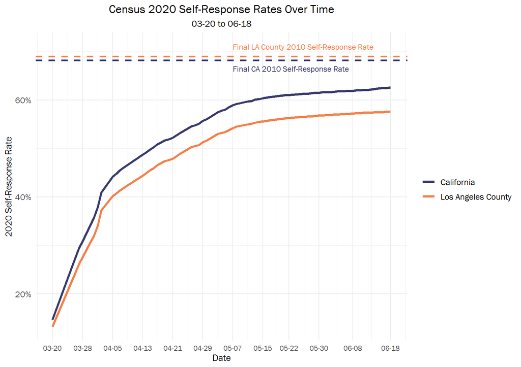

## Regional Self-Response Rates

- In LA County, the majority of hard-to-count census tracts have a lower response rate than the state rate and the county rate. However, we see a continuous creep upward in self-response rate, even in the regions with the largest concentration of HTC tracts.
- The hard work of CBOs doing Census outreach is reflected in the continuous, incremental increase in self-response rates.

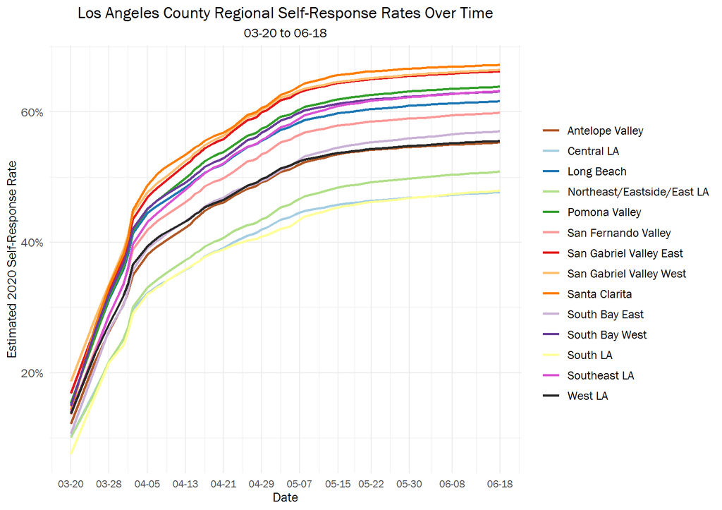

### Data Table

| Region | Current Response Rate (6/18) | Difference 6/03 to 6/18 | % Change 6/03 to 6/18 |
| --- | --- | --- | --- |
| Central LA | 47.7% | 0.7 | 1.4% |
| South LA | 47.9% | 0.9 | 1.9% |
| Northeast/Eastside/East LA | 50.8% | 0.8 | 1.6% |
| Antelope Valley | 55.3% | 0.5 | 1.0% |
| West LA | 55.5% | 0.6 | 1.1% |
| South Bay East | 57.0% | 0.8 | 1.5% |
| San Fernando Valley | 59.9% | 0.7 | 1.2% |
| Long Beach | 61.6% | 0.5 | 0.9% |
| South Bay West | 63.1% | 0.6 | 0.9% |
| Southeast LA | 63.2% | 0.7 | 1.1% |
| Pomona Valley | 63.9% | 0.5 | 0.9% |
| San Gabriel Valley East | 66.2% | 0.5 | 0.8% |
| San Gabriel Valley West | 66.5% | 0.6 | 0.8% |
| Santa Clarita | 67.2% | 0.4 | 0.6% |

Published by [Advancement Project California](https://www.advancementprojectca.org/)